# AirBnB Cape Town Findings

## The questions we are looking to answer

#### What factors effect an AirBNB's reviews per month?

#### Does the host's details effect the reviews per month?

#### What contributes to a good review?

```python
import numpy as np
import pandas as pd
import matplotlib.pyplot as plt
import seaborn as sns
from datetime import date
from sklearn.model_selection import train_test_split
from sklearn.linear_model import LinearRegression
from sklearn.metrics import r2_score
%matplotlib inline

df = pd.read_csv('./data/listings.csv')
schema = pd.read_csv('./data/listings_detail.csv')

df.head()
```

|  | id | listing_url | scrape_id | last_scraped | source | name | description | neighborhood_overview | picture_url | host_id | ... | review_scores_communication | review_scores_location | review_scores_value | license | instant_bookable | calculated_host_listings_count | calculated_host_listings_count_entire_homes | calculated_host_listings_count_private_rooms | calculated_host_listings_count_shared_rooms | reviews_per_month |
| --- | --- | --- | --- | --- | --- | --- | --- | --- | --- | --- | --- | --- | --- | --- | --- | --- | --- | --- | --- | --- | --- |
| 0 | 580121691775710190 | https://www.airbnb.com/rooms/580121691775710190 | 20230923041114 | 2023-09-23 | city scrape | Guest suite in Cape Town · 1 bedroom · 1 bed ·... | Our stunning, fully equipped apartment which i... | Camps Bay is a beautiful, trendy suburb in the... | https://a0.muscache.com/pictures/miso/Hosting-... | 63220399 | ... | 5.00 | 5.00 | 4.00 | NaN | f | 1 | 1 | 0 | 0 | 0.11 |
| 1 | 14411052 | https://www.airbnb.com/rooms/14411052 | 20230923041114 | 2023-09-23 | city scrape | Bungalow in Cape Town · ★4.84 · 4 bedrooms · 5... | Wake up to the sound of the ocean. Access the ... | The home is set along the scenic 4th Beach in ... | https://a0.muscache.com/pictures/5fc0e191-521d... | 37061965 | ... | 4.81 | 5.00 | 4.55 | NaN | t | 1 | 1 | 0 | 0 | 0.46 |
| 2 | 795213074769367680 | https://www.airbnb.com/rooms/795213074769367680 | 20230923041114 | 2023-09-23 | city scrape | Home in Cape Town · ★4.22 · 3 bedrooms · 3 bed... | Relax with the whole family at this peaceful a... | Very quite and peaceful neighbourhood | https://a0.muscache.com/pictures/miso/Hosting-... | 464004682 | ... | 4.44 | 4.22 | 4.22 | NaN | f | 5 | 5 | 0 | 0 | 1.04 |
| 3 | 919576600569436881 | https://www.airbnb.com/rooms/919576600569436881 | 20230923041114 | 2023-09-23 | city scrape | Bed and breakfast in Cape Town · 2 bedrooms · ... | You’ll be charmed by this adorable place to stay. | NaN | https://a0.muscache.com/pictures/miso/Hosting-... | 396041414 | ... | NaN | NaN | NaN | NaN | t | 1 | 0 | 1 | 0 | NaN |
| 4 | 898408833774725631 | https://www.airbnb.com/rooms/898408833774725631 | 20230923041114 | 2023-09-23 | city scrape | Serviced apartment in Cape Town · 2 bedrooms ·... | This spacious beach view apartment is located ... | Coffee Shops - Beach front, just down the road... | https://a0.muscache.com/pictures/miso/Hosting-... | 510626462 | ... | 5.00 | 5.00 | 5.00 | NaN | f | 12 | 10 | 2 | 0 | 1.00 |

5 rows × 75 columns

```python
df.shape
```

```
(21120, 75)
```

```python
num_null = df.isnull().sum()
num_null[num_null != 0]

# Columns that have NaN values in them
```

```
description                       240
neighborhood_overview            7647
host_location                    5153
host_about                       9969
host_response_time               5015
host_response_rate               5015
host_acceptance_rate             2486
host_is_superhost                 507
host_neighbourhood              21025
neighbourhood                    7647
neighbourhood_group_cleansed    21120
bathrooms                       21120
bathrooms_text                     32
bedrooms                         3878
beds                              284
minimum_minimum_nights              7
maximum_minimum_nights              7
minimum_maximum_nights              7
maximum_maximum_nights              7
minimum_nights_avg_ntm              7
maximum_nights_avg_ntm              7
calendar_updated                21120
first_review                     4914
last_review                      4914
review_scores_rating             4914
review_scores_accuracy           5019
review_scores_cleanliness        5017
review_scores_checkin            5023
review_scores_communication      5019
review_scores_location           5022
review_scores_value              5022
license                         21053
reviews_per_month                4914
dtype: int64
```

```python
num_null[num_null == df.shape[0]]

# Columns with all NaN values
```

```
neighbourhood_group_cleansed    21120
bathrooms                       21120
calendar_updated                21120
dtype: int64
```

```python
num_null[num_null > (0.75 * df.shape[0])]

# Columns with >75% of the values missing

# License is not applicable in South Africa
```

```
host_neighbourhood              21025
neighbourhood_group_cleansed    21120
bathrooms                       21120
calendar_updated                21120
license                         21053
dtype: int64
```

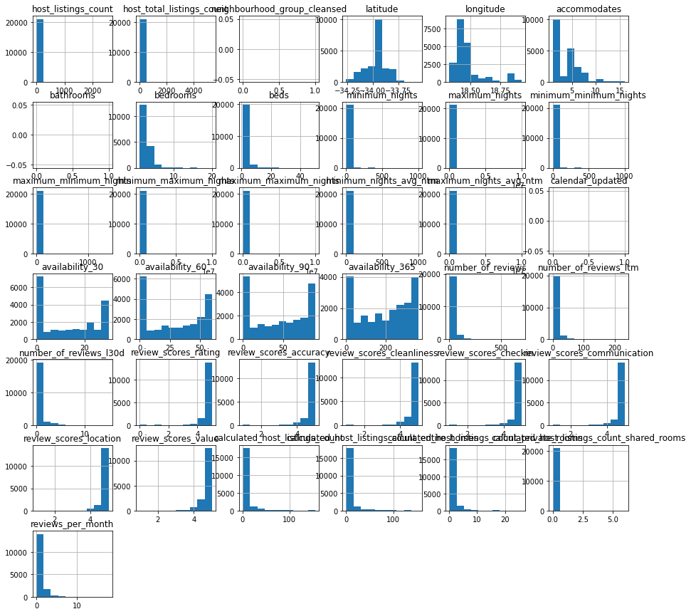

```python
df.drop(['id', 'scrape_id', 'host_id'], axis=1).hist(figsize=(15, 15));
```

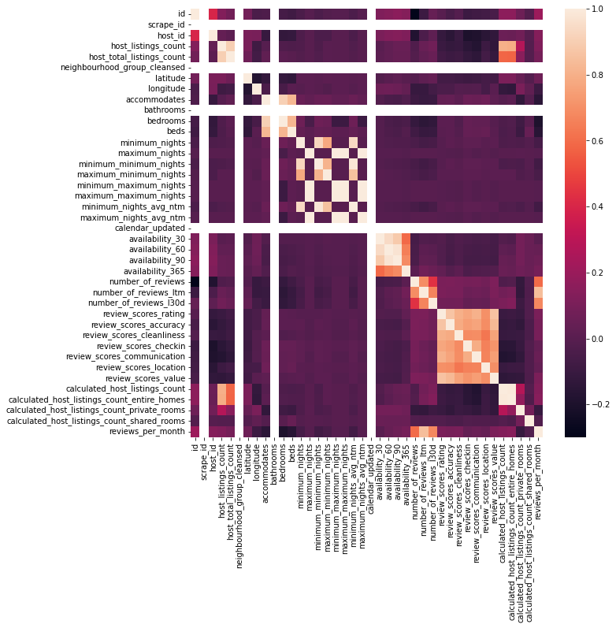

```python
plt.figure(figsize=(10,10))
sns.heatmap(df.corr()); # , annot=True, fmt='.2f'
```

### The above dataset is messy and many columns contain abstract data that we can't make meaningful information from.

### I am going to restructure the dataset and turn the abstract columns into data we can use to make predictions

```python
df_no_empty = df.dropna(how='all', axis=1)
df_no_empty.shape
```

```
(21120, 72)
```

```python
df_reduced = df_no_empty.drop(['id', 'name','listing_url', 'source', 'last_scraped', 'scrape_id', 'host_id', 'host_url', 'neighbourhood', 'latitude', 'longitude', 'property_type', 'calendar_last_scraped', 'license', 'picture_url', 'host_name', 'host_thumbnail_url', 'host_picture_url', 'host_neighbourhood', 'host_listings_count', 'host_total_listings_count', 'host_verifications', 'bathrooms_text', 'minimum_minimum_nights', 'maximum_minimum_nights', 'minimum_maximum_nights', 'maximum_maximum_nights', 'minimum_nights', 'maximum_nights', 'has_availability', 'host_response_rate', 'neighbourhood_cleansed'], axis=1);
```

### I decided to drop the 'neighbourhoof_cleansed' field as there is too little data points for each category and it leads to bad performance from the model

```python
def percentage_to_rate(percent):
    if (isinstance(percent, float)):
        return percent

    return float(percent.split("%")[0]) / 100

def airbnb_bool_to_bool(airbnb_bool):
    if (isinstance(airbnb_bool, int)):
        return airbnb_bool


    return 1 if airbnb_bool == "t" else 0

def months_since(date_str):
    if (isinstance(date_str, int)):
        return date_str

    years = int(date.today().year) - int(date_str.rsplit("-")[0])
    months = int(date.today().month) - int(date_str.rsplit("-")[1])

    total_months = (years * 12) + months

    return total_months if total_months >= 0 else 0

def price_to_float(price):
    if (isinstance(price, float)):
        return price

    return float(price.replace(",", "").replace("$", ""))
```

```python
df_reduced['listing_has_description'] = df_reduced['description'].notnull().replace({True: 1, False: 0})
df_reduced['listing_has_neighborhood_overview'] = df_reduced['neighborhood_overview'].notnull().replace({True: 1, False: 0})
df_reduced['host_months_on_airbnb'] = df_reduced['host_since'].map(months_since, na_action="ignore")
df_reduced['host_has_location'] = df_reduced['host_location'].notnull().replace({True: 1, False: 0})
df_reduced['host_has_about'] = df_reduced['host_about'].notnull().replace({True: 1, False: 0})
df_reduced['host_acceptance_rate'] = df_reduced['host_acceptance_rate'].map(percentage_to_rate, na_action="ignore")
df_reduced['host_is_superhost'] = df_reduced['host_is_superhost'].map(airbnb_bool_to_bool, na_action="ignore")
df_reduced['instant_bookable'] = df_reduced['instant_bookable'].map(airbnb_bool_to_bool, na_action="ignore")
df_reduced['host_has_profile_pic'] = df_reduced['host_has_profile_pic'].map(airbnb_bool_to_bool, na_action="ignore")
df_reduced['host_identity_verified'] = df_reduced['host_identity_verified'].map(airbnb_bool_to_bool, na_action="ignore")
df_reduced['price'] = df_reduced['price'].map(price_to_float, na_action="ignore")
df_reduced['months_since_last_review'] = df_reduced['last_review'].map(months_since, na_action="ignore")
df_reduced['months_since_first_review'] = df_reduced['first_review'].map(months_since, na_action="ignore")
df_reduced['listing_months_active'] = df_reduced['months_since_first_review']
```

```python
df_reduced.drop(['description', 'neighborhood_overview', 'host_since', 'host_location', 'host_about', 'last_review', 'first_review'], axis=1, inplace=True)
```

```python
df_reduced = df_reduced[df_reduced['months_since_last_review'] <= 12]

df_reduced.drop(['months_since_first_review', 'months_since_last_review'], axis=1, inplace=True)
```

```python
df_reduced
```

|  | host_response_time | host_acceptance_rate | host_is_superhost | host_has_profile_pic | host_identity_verified | room_type | accommodates | bedrooms | beds | amenities | ... | calculated_host_listings_count_entire_homes | calculated_host_listings_count_private_rooms | calculated_host_listings_count_shared_rooms | reviews_per_month | listing_has_description | listing_has_neighborhood_overview | host_months_on_airbnb | host_has_location | host_has_about | listing_months_active |
| --- | --- | --- | --- | --- | --- | --- | --- | --- | --- | --- | --- | --- | --- | --- | --- | --- | --- | --- | --- | --- | --- |
| 0 | within a day | 0.33 | 0.0 | 1 | 1 | Entire home/apt | 2 | 1.0 | 1.0 | ["Body soap", "Heating", "Dishes and silverwar... | ... | 1 | 0 | 0 | 0.11 | 1 | 1 | 93 | 0 | 0 | 11.0 |
| 1 | within a few hours | 1.00 | 0.0 | 1 | 1 | Entire home/apt | 8 | 4.0 | 5.0 | ["Body soap", "Heating", "Dishes and silverwar... | ... | 1 | 0 | 0 | 0.46 | 1 | 1 | 102 | 1 | 1 | 85.0 |
| 2 | within an hour | 1.00 | 0.0 | 1 | 1 | Entire home/apt | 5 | 3.0 | 3.0 | ["Wifi", "Free parking on premises", "TV", "Ki... | ... | 5 | 0 | 0 | 1.04 | 1 | 1 | 18 | 1 | 1 | 11.0 |
| 4 | within a day | 0.62 | 0.0 | 1 | 1 | Entire home/apt | 4 | 2.0 | 9.0 | ["Heating", "Dishes and silverware", "Free was... | ... | 10 | 2 | 0 | 1.00 | 1 | 1 | 8 | 1 | 1 | 3.0 |
| 5 | within an hour | 0.89 | 1.0 | 1 | 1 | Entire home/apt | 8 | 4.0 | 4.0 | ["Heating", "Dishes and silverware", "Free was... | ... | 14 | 0 | 0 | 1.65 | 1 | 0 | 95 | 1 | 0 | 11.0 |
| ... | ... | ... | ... | ... | ... | ... | ... | ... | ... | ... | ... | ... | ... | ... | ... | ... | ... | ... | ... | ... | ... |
| 21114 | within an hour | 0.91 | 0.0 | 1 | 1 | Entire home/apt | 2 | 1.0 | 1.0 | ["Body soap", "Heating", "Dishes and silverwar... | ... | 73 | 0 | 0 | 0.66 | 1 | 1 | 31 | 1 | 0 | 13.0 |
| 21116 | within an hour | 0.94 | 1.0 | 1 | 1 | Entire home/apt | 4 | 2.0 | 3.0 | ["AC - split type ductless system", "Cleaning ... | ... | 1 | 0 | 0 | 2.83 | 1 | 1 | 131 | 1 | 1 | 31.0 |
| 21117 | NaN | 0.67 | 0.0 | 1 | 1 | Entire home/apt | 2 | 1.0 | 1.0 | ["Extra pillows and blankets", "Paid washer \u... | ... | 1 | 0 | 0 | 0.10 | 1 | 1 | 80 | 1 | 0 | 23.0 |
| 21118 | within a few hours | 1.00 | 1.0 | 1 | 1 | Entire home/apt | 8 | 4.0 | 5.0 | ["Mini fridge", "Cleaning products", "Heating"... | ... | 1 | 0 | 0 | 1.31 | 1 | 1 | 108 | 1 | 0 | 101.0 |
| 21119 | within an hour | 0.94 | 1.0 | 1 | 1 | Entire home/apt | 4 | 2.0 | 2.0 | ["AC - split type ductless system", "Cleaning ... | ... | 26 | 0 | 0 | 0.98 | 1 | 1 | 96 | 1 | 1 | 18.0 |

13005 rows × 39 columns

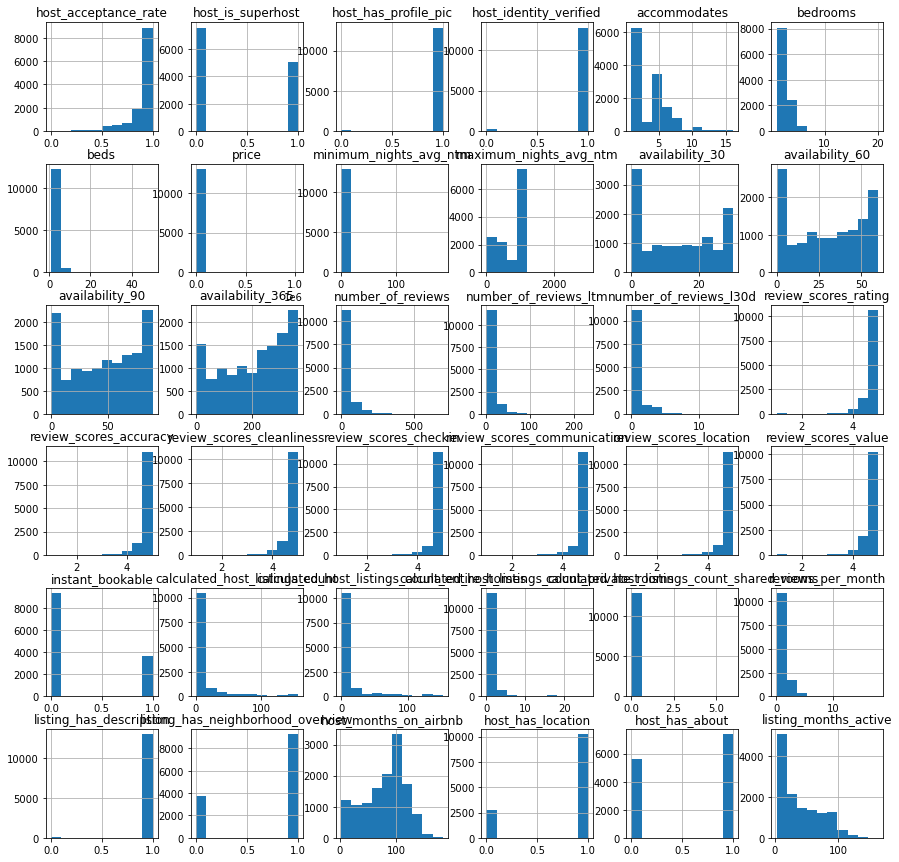

```python
df_reduced.hist(figsize=(15, 15));
```

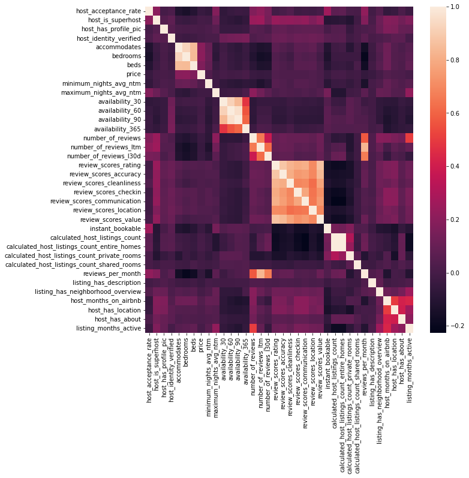

```python
plt.figure(figsize=(10,10))
sns.heatmap(df_reduced.corr());
```

### I will be using df_reduced for the rest of the notebook and treat it as the input data

```python
def clean_amenities(df, max_amenities = 0):
    if max_amenities == 0:
        df.drop('amenities', inplace=True, axis=1)
        return {}

    amenities_dict = {}

    for row in df['amenities']:
        options = row.strip('][').replace('"', '').split(', ')

        for amenity in options:
            amenity_name = "amenities_" + amenity.replace(" ", "_")

            if amenity_name in amenities_dict:
                amenities_dict[amenity_name] += 1
            else:
                amenities_dict[amenity_name] = 1

    amenities_list = sorted(amenities_dict.items(), key=lambda x:x[1], reverse=True)

    amenities_dict_limitted = dict(amenities_list[:max_amenities])

    df.reset_index(inplace=True, drop=True)

    for amenities_name in amenities_dict_limitted:
        df[amenities_name] = 0

    for i in range(df.shape[0]):
        am = df.at[i, 'amenities']
        options = am.strip('][').replace('"', '').split(', ')

        for amenity in options:
            amenity_name = "amenities_" + amenity.replace(" ", "_")

            if amenity_name in amenities_dict_limitted:
                df.at[i, amenity_name] = 1

    df.drop('amenities', inplace=True, axis=1)

    return amenities_dict_limitted
```

```python
def clean_data(df, target_column, max_amenities = 365):
    '''
    INPUT
    df - pandas dataframe
    target_column - Column being used as the target column (column to predict)
    max_amenities - The top x amount of amenities to keep

    OUTPUT
    X - A matrix holding all of the variables you want to consider when predicting the response
    y - the corresponding response vector
    '''
    # Drop rows with missing salary values
    df.dropna(subset=[target_column], axis=0, inplace=True)

    y = df[target_column]
    df = df.drop(target_column, axis=1)

    # Fill numeric values
    df['host_acceptance_rate'].fillna(df['host_acceptance_rate'].mean(), inplace=True)
    df['host_is_superhost'].fillna(0, inplace=True)
    df['bedrooms'].fillna(0, inplace=True)
    df['beds'].fillna(0, inplace=True)
    df['minimum_nights_avg_ntm'].fillna(1, inplace=True)
    df['maximum_nights_avg_ntm'].fillna(3000, inplace=True)

    for col in ['review_scores_accuracy', 'review_scores_cleanliness', 'review_scores_checkin', 'review_scores_communication', 'review_scores_location', 'review_scores_value']:
        if 'review_scores_rating' in df.columns:
            df[col].fillna(df['review_scores_rating'], inplace=True)
        else:
            df[col].fillna(df[col].mean(), inplace=True)

    # Deal with amenities
    amenities_dict = clean_amenities(df, max_amenities)

    df = pd.get_dummies(df, columns=df.select_dtypes(include=['object']).columns, dummy_na=True)

    if 'room_type_nan' in df.columns:
        df.drop(['room_type_nan'], axis=1, inplace=True)

    X = df
    return X, y

#Use the function to create X and y
X, y = clean_data(df_reduced, 'reviews_per_month', 100)
X
```

|  | host_acceptance_rate | host_is_superhost | host_has_profile_pic | host_identity_verified | accommodates | bedrooms | beds | price | minimum_nights_avg_ntm | maximum_nights_avg_ntm | ... | amenities_Babysitter_recommendations | host_response_time_a few days or more | host_response_time_within a day | host_response_time_within a few hours | host_response_time_within an hour | host_response_time_nan | room_type_Entire home/apt | room_type_Hotel room | room_type_Private room | room_type_Shared room |
| --- | --- | --- | --- | --- | --- | --- | --- | --- | --- | --- | --- | --- | --- | --- | --- | --- | --- | --- | --- | --- | --- |
| 0 | 0.33 | 0.0 | 1 | 1 | 2 | 1.0 | 1.0 | 3000.0 | 7.0 | 1125.0 | ... | 0 | 0 | 1 | 0 | 0 | 0 | 1 | 0 | 0 | 0 |
| 1 | 1.00 | 0.0 | 1 | 1 | 8 | 4.0 | 5.0 | 13174.0 | 3.0 | 1125.0 | ... | 0 | 0 | 0 | 1 | 0 | 0 | 1 | 0 | 0 | 0 |
| 2 | 1.00 | 0.0 | 1 | 1 | 5 | 3.0 | 3.0 | 1478.0 | 2.0 | 1125.0 | ... | 0 | 0 | 0 | 0 | 1 | 0 | 1 | 0 | 0 | 0 |
| 3 | 0.62 | 0.0 | 1 | 1 | 4 | 2.0 | 9.0 | 2177.0 | 2.1 | 28.0 | ... | 0 | 0 | 1 | 0 | 0 | 0 | 1 | 0 | 0 | 0 |
| 4 | 0.89 | 1.0 | 1 | 1 | 8 | 4.0 | 4.0 | 7658.0 | 4.0 | 1125.0 | ... | 0 | 0 | 0 | 0 | 1 | 0 | 1 | 0 | 0 | 0 |
| ... | ... | ... | ... | ... | ... | ... | ... | ... | ... | ... | ... | ... | ... | ... | ... | ... | ... | ... | ... | ... | ... |
| 13000 | 0.91 | 0.0 | 1 | 1 | 2 | 1.0 | 1.0 | 1913.0 | 1.0 | 28.0 | ... | 0 | 0 | 0 | 0 | 1 | 0 | 1 | 0 | 0 | 0 |
| 13001 | 0.94 | 1.0 | 1 | 1 | 4 | 2.0 | 3.0 | 2093.0 | 1.1 | 1125.0 | ... | 1 | 0 | 0 | 0 | 1 | 0 | 1 | 0 | 0 | 0 |
| 13002 | 0.67 | 0.0 | 1 | 1 | 2 | 1.0 | 1.0 | 1000.0 | 2.0 | 365.0 | ... | 0 | 0 | 0 | 0 | 0 | 1 | 1 | 0 | 0 | 0 |
| 13003 | 1.00 | 1.0 | 1 | 1 | 8 | 4.0 | 5.0 | 15000.0 | 4.0 | 1125.0 | ... | 1 | 0 | 0 | 1 | 0 | 0 | 1 | 0 | 0 | 0 |
| 13004 | 0.94 | 1.0 | 1 | 1 | 4 | 2.0 | 2.0 | 2900.0 | 4.0 | 1125.0 | ... | 0 | 0 | 0 | 0 | 1 | 0 | 1 | 0 | 0 | 0 |

13005 rows × 144 columns

```python
def create_model(X, y):
    '''
    Creates a linear predictive model from the given inputs

    INPUT:
        X: pd.DataFrame - Dataframe containing all the features
        y: pd.Series - The target column

    OUTPUT:
        linear_model - The fitted model from the data
        train_score - The R2 Score from the training data
        test_score - The R2 Score from the testing data
        X_train - The training data based on the train/test split
    '''

    X_train, X_test, y_train, y_test = train_test_split(X, y, test_size = .30, random_state=42)

    linear_model = LinearRegression(normalize=True)
    linear_model.fit(X_train, y_train)

    y_test_preds = linear_model.predict(X_test)
    y_train_preds = linear_model.predict(X_train)

    test_score = r2_score(y_test, y_test_preds)
    train_score = r2_score(y_train, y_train_preds)

    return linear_model, train_score, test_score, X_train
```

```python
linear_model, train_score, test_score, X_train = create_model(X, y)
```

```python
print("The rsquared on the training data was {}.  The rsquared on the test data was {}.".format(train_score, test_score))
```

```
The rsquared on the training data was 0.8035513063851688.  The rsquared on the test data was 0.7731605780992017.
```

```python
def coef_weights(coefficients, X_train):
    '''
    INPUT:
    coefficients - the coefficients of the linear model
    X_train - the training data, so the column names can be used
    OUTPUT:
    coefs_df - a dataframe holding the coefficient, estimate, and abs(estimate)

    Provides a dataframe that can be used to understand the most influential coefficients
    in a linear model by providing the coefficient estimates along with the name of the
    variable attached to the coefficient.
    '''
    coefs_df = pd.DataFrame()
    coefs_df['est_int'] = X_train.columns
    coefs_df['coefs'] = coefficients
    coefs_df['abs_coefs'] = np.abs(coefficients)
    coefs_df = coefs_df.sort_values('abs_coefs', ascending=False)
    return coefs_df

#Use the function
coef_df = coef_weights(linear_model.coef_, X_train)

#A quick look at the top results
coef_df.head(20)
```

|  | est_int | coefs | abs_coefs |
| --- | --- | --- | --- |
| 141 | room_type_Hotel room | 1.449419e+12 | 1.449419e+12 |
| 140 | room_type_Entire home/apt | 1.449419e+12 | 1.449419e+12 |
| 142 | room_type_Private room | 1.449419e+12 | 1.449419e+12 |
| 143 | room_type_Shared room | 1.449419e+12 | 1.449419e+12 |
| 135 | host_response_time_a few days or more | -5.952474e+10 | 5.952474e+10 |
| 139 | host_response_time_nan | -5.952474e+10 | 5.952474e+10 |
| 136 | host_response_time_within a day | -5.952474e+10 | 5.952474e+10 |
| 137 | host_response_time_within a few hours | -5.952474e+10 | 5.952474e+10 |
| 138 | host_response_time_within an hour | -5.952474e+10 | 5.952474e+10 |
| 16 | number_of_reviews_l30d | 1.705508e-01 | 1.705508e-01 |
| 23 | review_scores_value | 1.279938e-01 | 1.279938e-01 |
| 17 | review_scores_rating | -8.406444e-02 | 8.406444e-02 |
| 41 | amenities_Hot_water | 7.461817e-02 | 7.461817e-02 |
| 29 | listing_has_description | 6.662507e-02 | 6.662507e-02 |
| 38 | amenities_Hangers | -6.616688e-02 | 6.616688e-02 |
| 58 | amenities_Cleaning_products | 6.596302e-02 | 6.596302e-02 |
| 2 | host_has_profile_pic | 6.234936e-02 | 6.234936e-02 |
| 28 | calculated_host_listings_count_shared_rooms | 5.992846e-02 | 5.992846e-02 |
| 19 | review_scores_cleanliness | 5.865658e-02 | 5.865658e-02 |
| 83 | amenities_Self_check-in | 5.856060e-02 | 5.856060e-02 |

### I am going to test the effect of the amount of amenities used on the performance of the model

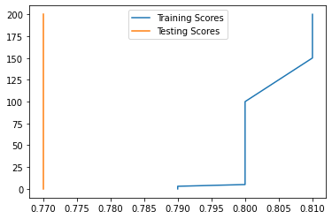

```python
num_amenities = [0, 1, 3, 5, 10, 50, 100, 150, 200]

train_scores = []
test_scores = []

for num in num_amenities:
    X, y = clean_data(df_reduced, 'reviews_per_month', num)
    lm_model, train_score, test_score, X_train = create_model(X, y)

    train_scores.append(round(train_score, 2))
    test_scores.append(round(test_score, 2))

plt.plot(train_scores, num_amenities, label='Training Scores')
plt.plot(test_scores, num_amenities, label='Testing Scores')
plt.legend()
plt.show()
```

#### The graph seems to indicate increasing the amount of amenities has no direct effect on how well the model performs. Whether we use 0 or 200 amenities, the model performs the same (although it is different on the training data but this could be due to overfitting).

```python
def test_amenities(df, output_col, num_amenities = [0, 1, 3, 5, 10, 50, 100, 150, 200]):
    '''
    Compares the linear models from the data against one another with a different amount of amenities used.

    INPUT:
        df: pd.DataFrame - Dataframe containing all the features as well as the target column
        output_col: string - The name of the desired target column
        num_amenities: list<string> - A list containg the number of amenities for each iteration

    OUTPUT:
        best_score: dictionary - A dictionary containing the model, training data and score for the best performing model
    '''

    best_score = {"model": None, "X_train": None, "score": 0}
    train_scores = []
    test_scores = []

    for num in num_amenities:
        X, y = clean_data(df, output_col, num)
        lm_model, train_score, test_score, X_train = create_model(X, y)

        if test_score >= best_score["score"]:
            best_score["score"]= test_score
            best_score["X_train"] = X_train
            best_score["model"] = lm_model

        train_scores.append(round(train_score, 2))
        test_scores.append(round(test_score, 2))

    plt.plot(train_scores, num_amenities, label='Training Scores')
    plt.plot(test_scores, num_amenities, label='Testing Scores')
    plt.title("Predicting " + output_col)
    plt.xlabel('R2 Score')
    plt.ylabel('Number of amenities')
    plt.legend()
    plt.show()

    return best_score
```

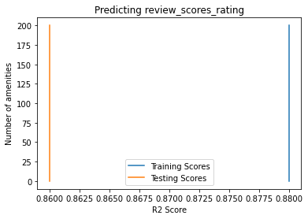

```python
best_score = test_amenities(df_reduced, 'review_scores_rating')
```

```python
model_coef = coef_weights(best_score['model'].coef_, best_score['X_train']).head(20)
model_coef
```

|  | est_int | coefs | abs_coefs |
| --- | --- | --- | --- |
| 48 | host_response_time_within an hour | -2.533291e+11 | 2.533291e+11 |
| 47 | host_response_time_within a few hours | -2.533291e+11 | 2.533291e+11 |
| 46 | host_response_time_within a day | -2.533291e+11 | 2.533291e+11 |
| 45 | host_response_time_a few days or more | -2.533291e+11 | 2.533291e+11 |
| 49 | host_response_time_nan | -2.533291e+11 | 2.533291e+11 |
| 50 | room_type_Entire home/apt | 5.874842e+10 | 5.874842e+10 |
| 52 | room_type_Private room | 5.874842e+10 | 5.874842e+10 |
| 53 | room_type_Shared room | 5.874842e+10 | 5.874842e+10 |
| 51 | room_type_Hotel room | 5.874842e+10 | 5.874842e+10 |
| 17 | review_scores_accuracy | 2.809477e-01 | 2.809477e-01 |
| 22 | review_scores_value | 2.658610e-01 | 2.658610e-01 |
| 18 | review_scores_cleanliness | 2.015500e-01 | 2.015500e-01 |
| 19 | review_scores_checkin | 1.598455e-01 | 1.598455e-01 |
| 20 | review_scores_communication | 1.345604e-01 | 1.345604e-01 |
| 29 | listing_has_description | -4.975895e-02 | 4.975895e-02 |
| 0 | host_acceptance_rate | -2.386806e-02 | 2.386806e-02 |
| 21 | review_scores_location | 2.346871e-02 | 2.346871e-02 |
| 3 | host_identity_verified | 2.104829e-02 | 2.104829e-02 |
| 1 | host_is_superhost | 1.970711e-02 | 1.970711e-02 |
| 35 | amenities_Kitchen | 9.981952e-03 | 9.981952e-03 |

```
<BarContainer object of 11 artists>
```

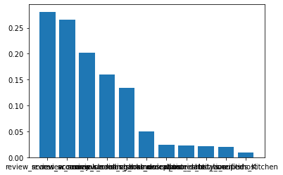

```python
model_coef = model_coef.iloc[9:]
plt.bar(model_coef.est_int, model_coef.abs_coefs)
```

### Looking as the coefficients, the host response time and the room type have the same values for each category. This could suggest that they have no role in predicting the review rating or the reviews per month.

### I am going to experiment with a dataset that has those two columns dropped.

```python
df_test = df_reduced
```

```python
df_test.drop(['host_response_time', 'room_type'], inplace=True, axis=1)
```

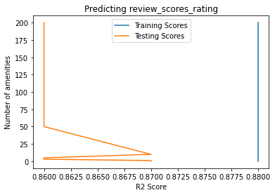

```python
best_test_score = test_amenities(df_test, 'review_scores_rating')
```

```python
coef_weights(best_test_score['model'].coef_, best_test_score['X_train']).head(20)
```

|  | est_int | coefs | abs_coefs |
| --- | --- | --- | --- |
| 17 | review_scores_accuracy | 0.280649 | 0.280649 |
| 22 | review_scores_value | 0.265468 | 0.265468 |
| 18 | review_scores_cleanliness | 0.202813 | 0.202813 |
| 19 | review_scores_checkin | 0.160578 | 0.160578 |
| 20 | review_scores_communication | 0.134896 | 0.134896 |
| 29 | listing_has_description | -0.048881 | 0.048881 |
| 0 | host_acceptance_rate | -0.029892 | 0.029892 |
| 21 | review_scores_location | 0.023519 | 0.023519 |
| 1 | host_is_superhost | 0.017813 | 0.017813 |
| 3 | host_identity_verified | 0.014731 | 0.014731 |
| 28 | reviews_per_month | -0.009553 | 0.009553 |
| 2 | host_has_profile_pic | 0.009155 | 0.009155 |
| 35 | amenities_Kitchen | 0.008845 | 0.008845 |
| 32 | host_has_location | -0.007083 | 0.007083 |
| 27 | calculated_host_listings_count_shared_rooms | -0.004102 | 0.004102 |
| 4 | accommodates | 0.003978 | 0.003978 |
| 30 | listing_has_neighborhood_overview | 0.003833 | 0.003833 |
| 23 | instant_bookable | -0.003540 | 0.003540 |
| 24 | calculated_host_listings_count | -0.003169 | 0.003169 |
| 25 | calculated_host_listings_count_entire_homes | 0.003088 | 0.003088 |

### After investigation, I am going to use the top 10 amenities with the df_test dataset (which removes the room_type and response_time). I will make all my conclusions from the results below

## Reviews Per Month model

```python
rpm_X, rpm_y = clean_data(df_test, 'reviews_per_month', 10)
rpm_model, rpm_train_score, rpm_test_score, rpm_X_train = create_model(rpm_X, rpm_y)

print("The rsquared on the training data was {}.  The rsquared on the test data was {}.".format(rpm_train_score, rpm_test_score))

rpm_coef = coef_weights(rpm_model.coef_, rpm_X_train).head(15)
rpm_coef
```

```
The rsquared on the training data was 0.7950722015362146.  The rsquared on the test data was 0.767101468677851.
```

|  | est_int | coefs | abs_coefs |
| --- | --- | --- | --- |
| 16 | number_of_reviews_l30d | 0.178371 | 0.178371 |
| 23 | review_scores_value | 0.127095 | 0.127095 |
| 0 | host_acceptance_rate | 0.111136 | 0.111136 |
| 17 | review_scores_rating | -0.103773 | 0.103773 |
| 29 | listing_has_description | 0.080143 | 0.080143 |
| 41 | amenities_Hot_water | 0.075678 | 0.075678 |
| 19 | review_scores_cleanliness | 0.074459 | 0.074459 |
| 38 | amenities_Hangers | -0.072293 | 0.072293 |
| 2 | host_has_profile_pic | 0.067114 | 0.067114 |
| 22 | review_scores_location | -0.062795 | 0.062795 |
| 44 | amenities_Bed_linens | 0.050458 | 0.050458 |
| 43 | amenities_Hair_dryer | 0.050263 | 0.050263 |
| 39 | amenities_Dishes_and_silverware | 0.046897 | 0.046897 |
| 3 | host_identity_verified | 0.045918 | 0.045918 |
| 15 | number_of_reviews_ltm | 0.045368 | 0.045368 |

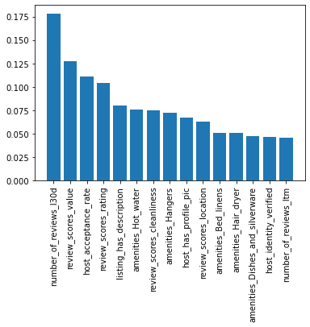

```python
plt.bar(rpm_coef.est_int, rpm_coef.abs_coefs)
plt.xticks(rotation=90)
plt.show()
```

From the graph above, we can see what factors effect the average reviews per a month (which correlates to the amount of bookings a listing gets per a month in a directly proportional manner). Some of the notable factors are: review score value, host acceptance rate and the review scores rating. It should also be noted that host details such as: profile picutre and identity verified do seem to contribute to more reviews per month.

## Rating model

```python
rsr_X, rsr_y = clean_data(df_test, 'review_scores_rating', 10)
rsr_model, rsr_train_score, rsr_test_score, rsr_X_train = create_model(rsr_X, rsr_y)

print("The rsquared on the training data was {}.  The rsquared on the test data was {}.".format(rsr_train_score, rsr_test_score))

rsr_coef = coef_weights(rsr_model.coef_, rsr_X_train).head(15)
rsr_coef
```

```
The rsquared on the training data was 0.8787224033465894.  The rsquared on the test data was 0.8650297982941956.
```

|  | est_int | coefs | abs_coefs |
| --- | --- | --- | --- |
| 17 | review_scores_accuracy | 0.280928 | 0.280928 |
| 22 | review_scores_value | 0.265535 | 0.265535 |
| 18 | review_scores_cleanliness | 0.201532 | 0.201532 |
| 19 | review_scores_checkin | 0.160770 | 0.160770 |
| 20 | review_scores_communication | 0.134684 | 0.134684 |
| 29 | listing_has_description | -0.049745 | 0.049745 |
| 0 | host_acceptance_rate | -0.031731 | 0.031731 |
| 21 | review_scores_location | 0.023233 | 0.023233 |
| 1 | host_is_superhost | 0.017206 | 0.017206 |
| 3 | host_identity_verified | 0.015112 | 0.015112 |
| 35 | amenities_Kitchen | 0.010682 | 0.010682 |
| 28 | reviews_per_month | -0.010007 | 0.010007 |
| 43 | amenities_Hair_dryer | 0.008851 | 0.008851 |
| 2 | host_has_profile_pic | 0.007388 | 0.007388 |
| 32 | host_has_location | -0.006918 | 0.006918 |

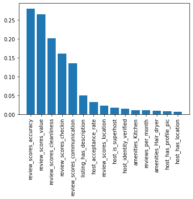

```python
plt.bar(rsr_coef.est_int, rsr_coef.abs_coefs)
plt.xticks(rotation=90)
plt.show()
```

The aim with this model is to find out what effects a good review from users. As suspected, the review scores dictate how the user scores their overall experience with a listing but looking at the graph, each scoring category seems to carry different weighting to a user. According to our model, users values (in order): listing accuracy, value for money, cleaniliness, checkin process and finally communication. It makes sense that communication is last when we found that the time it took for hosts to respond to users didn't have an impact on how they rated a property. There is a big difference between the effect that the review scores have on the final rating versus the rest of the columns; we could say that by looking at those scores we can be pretty sure as to how the user will rate their overall experience.